# Análisis estadístico de datos del “Kepler Space Observatory (KSO)” objetos de interés candidatos a ser exoplanetas

### OBJETIVO:

> *Conocer la relación entre la temperatura de un planeta, su radio y el radio de la estrella que orbita.

En la primera y segunda parte del proyecto se halló que la distribución de los datos recopilados por el satélite kepler no es normal.

```r
library(rio)
pl_0<- read.csv('/Users/114738/OneDrive/Escritorio/Proyectos/cumulative.csv', header = T);

pl_1<- dplyr::select(pl_0,kepoi_name, koi_prad, koi_srad, koi_teq)

attach(pl_1)
library(dplyr)

pl_1 <- pl_1 %>% group_by(kepoi_name) %>%   # %>% operador pipe
  dplyr::filter (! duplicated(kepoi_name))
pl_1<-drop_na(pl_1)
pl_m<-pl_1[2:4]

#Multiplicamos los radios de los planetas por 0.00916794 para que ambos radios se midan en radios solares.

pl_m$koi_prad<-pl_m$koi_prad*0.00916794
```

### Gráficas

Para poder estimar un modelo adecuado a nuestros datos y nuestro objetivo, primero utilizaremos la función “ggpairs” que nos permite comparar el compartamiento de las variables par a par.

```r
library(GGally)
```

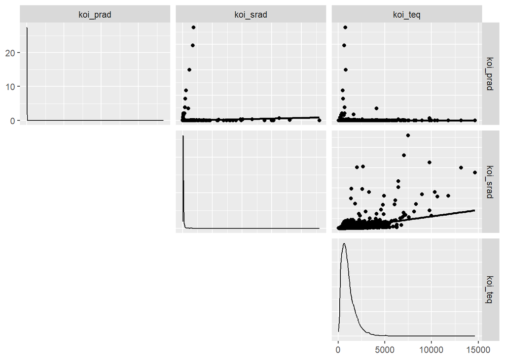

```r
ggpairs(pl_m, upper = list(continuous = "smooth"),
                      lower = list(continuous = "blank"),
                      diag = list(continuous = "densityDiag"))
```

Haciendo un rápido analisis a las gráficas, notamos que la única gáfica que presenta una tendencia relativamente evidente, es el diagrama entre el radio solar y la temperatura del planeta.

Ahora buscamos una corelación entre nuestras variables para nuestro análisis.

```r
library("Hmisc")
rcorr(as.matrix(pl_m))  # los datos deben estar como matriz
```

```
##          koi_prad koi_srad koi_teq
## koi_prad     1.00     0.06    0.00
## koi_srad     0.06     1.00    0.44
## koi_teq      0.00     0.44    1.00
##
## n= 9201
##
##
## P
##          koi_prad koi_srad koi_teq
## koi_prad          0.0000   0.9046
## koi_srad 0.0000            0.0000
## koi_teq  0.9046   0.0000
```

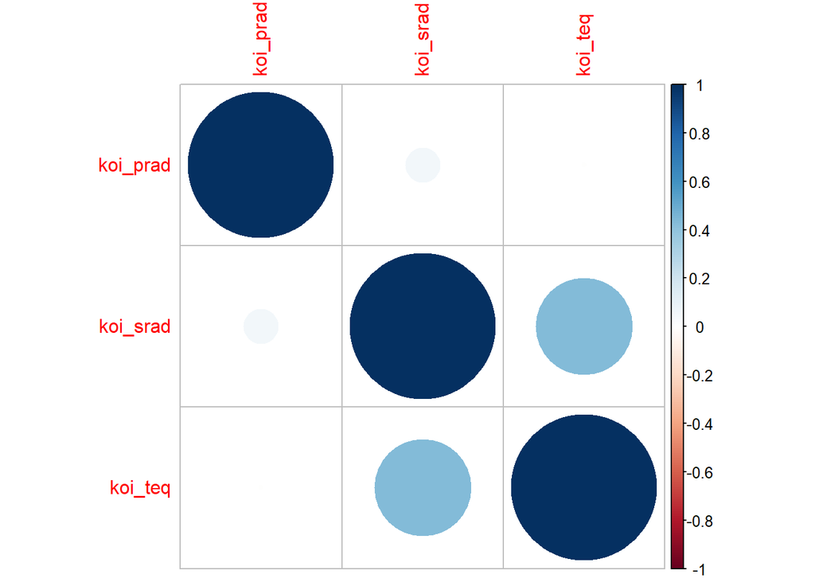

```r
# Una gráfica más

library(corrplot)
corrplot(cor(pl_m))   # correlograma
```

Notamos que no hay correlación entre el radio del sol y el del planeta. Pero existe una correlación entre el radio del sol y la temperatura del planeta.

### Estimación del modelo múltiple usando R

```r
modelo1<- lm(pl_m$koi_teq~pl_m$koi_srad+pl_m$koi_prad, data = pl_m)  # con    todos los predictores
summary(modelo1)
```

```
##
## Call:
## lm(formula = pl_m$koi_teq ~ pl_m$koi_srad + pl_m$koi_prad, data = pl_m)
##
## Residuals:
##     Min      1Q  Median      3Q     Max
## -8306.2  -510.6  -180.1   311.8  7060.8
##
## Coefficients:
##               Estimate Std. Error t value Pr(>|t|)
## (Intercept)   979.5051     8.3292 117.600  < 2e-16 ***
## pl_m$koi_srad  61.6833     1.3103  47.076  < 2e-16 ***
## pl_m$koi_prad  -0.7970     0.2845  -2.801  0.00511 **
## ---
## Signif. codes:  0 '***' 0.001 '**' 0.01 '*' 0.05 '.' 0.1 ' ' 1
##
## Residual standard error: 768.8 on 9198 degrees of freedom
## Multiple R-squared:  0.1942, Adjusted R-squared:  0.194
## F-statistic:  1108 on 2 and 9198 DF,  p-value: < 2.2e-16
```

```r
# Error estandar de los coeficientes en R (manual)

sqrt(diag(vcov(modelo1)))
```

```
##   (Intercept) pl_m$koi_srad pl_m$koi_prad
##     8.3291557     1.3102891     0.2845369
```

```r
# Criterio VIF
library(car)
vif(modelo1)
```

```
## pl_m$koi_srad pl_m$koi_prad
##      1.003222      1.003222
```

```r
tol<- 1/vif(modelo1); tol
```

```
## pl_m$koi_srad pl_m$koi_prad
##     0.9967886     0.9967886
```

## En búsqueda de un nuevo modelo: selección de los mejores predictores (regresores)

```r
step(object = modelo1, direction = "both", trace = 1)  # stepwise mixto
```

```
## Start:  AIC=122281.6
## pl_m$koi_teq ~ pl_m$koi_srad + pl_m$koi_prad
##
##                 Df  Sum of Sq        RSS    AIC
## <none>                        5436764341 122282
## - pl_m$koi_prad  1    4637319 5441401661 122287
## - pl_m$koi_srad  1 1309928401 6746692743 124266
```

```
##
## Call:
## lm(formula = pl_m$koi_teq ~ pl_m$koi_srad + pl_m$koi_prad, data = pl_m)
##
## Coefficients:
##   (Intercept)  pl_m$koi_srad  pl_m$koi_prad
##       979.505         61.683         -0.797
```

# Modelo 2

Proponemos un segundo modelo esta vez considerando una sola de las variables “Radio Solar”.

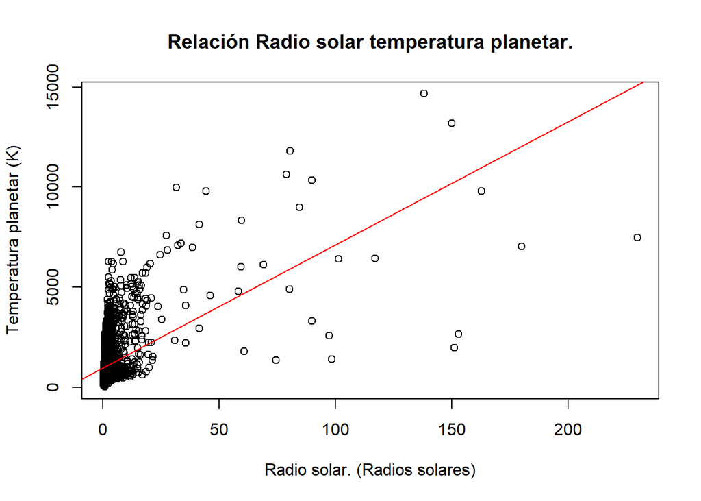

```r
modelo2<- lm(pl_m$koi_teq~pl_m$koi_srad, data = pl_m)

plot(pl_m$koi_srad,pl_m$koi_teq,pch=1,xlab="Radio solar. (Radios solares)",ylab="Temperatura planetar (K)", main="Relación Radio solar temperatura planetar.")

abline(modelo2,col="red")
```

```r
summary(modelo2)
```

```
##
## Call:
## lm(formula = pl_m$koi_teq ~ pl_m$koi_srad, data = pl_m)
##
## Residuals:
##     Min      1Q  Median      3Q     Max
## -8276.2  -511.1  -179.9   312.3  7067.4
##
## Coefficients:
##               Estimate Std. Error t value Pr(>|t|)
## (Intercept)    979.113      8.331  117.53   <2e-16 ***
## pl_m$koi_srad   61.475      1.309   46.98   <2e-16 ***
## ---
## Signif. codes:  0 '***' 0.001 '**' 0.01 '*' 0.05 '.' 0.1 ' ' 1
##
## Residual standard error: 769.1 on 9199 degrees of freedom
## Multiple R-squared:  0.1935, Adjusted R-squared:  0.1934
## F-statistic:  2207 on 1 and 9199 DF,  p-value: < 2.2e-16
```

Notamos que para este segundo modelo el valor de R-cuadrada disminuyo muy poco mientras que el error medio aumento . Esto quiere decir que no estro segúndo modelo esta explicando menos el cambio en la temperatura del planeta. Algo que es alentador es que el error para el intercepto y la variable $\beta_1$ tiene menor peso que el modelo anterior.

Para poder obtener un modelo adecuado vamos a hacer un analisis al conjunto de datos y así determinar si los datos atipicos son los que están provocando estos errores tan grandes en el modelo.

# Gráficas de diagnostico.

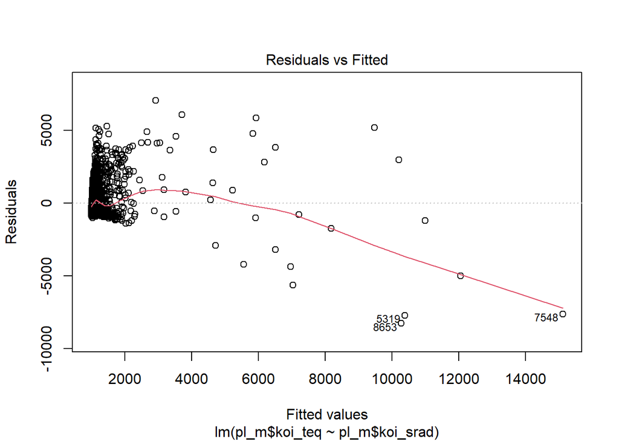

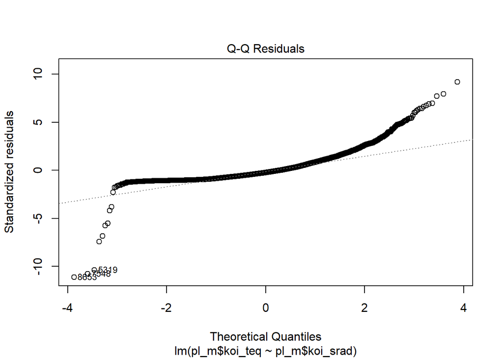

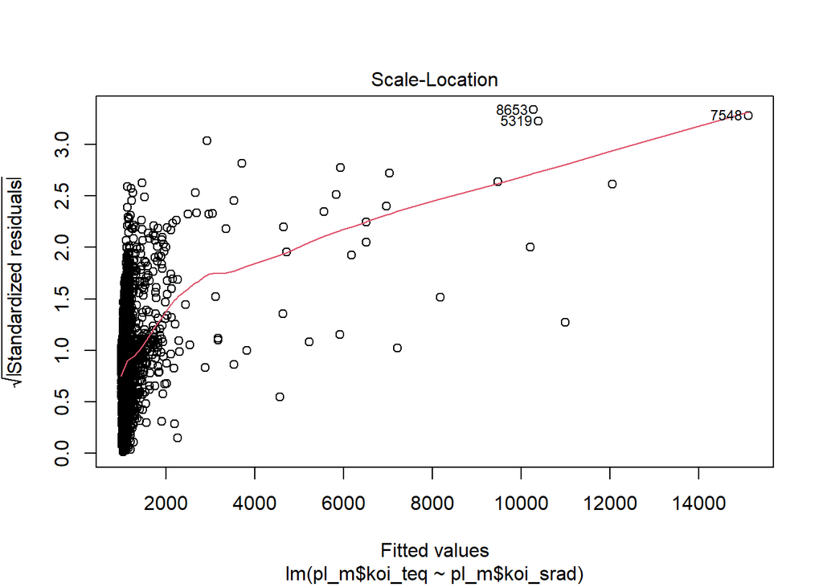

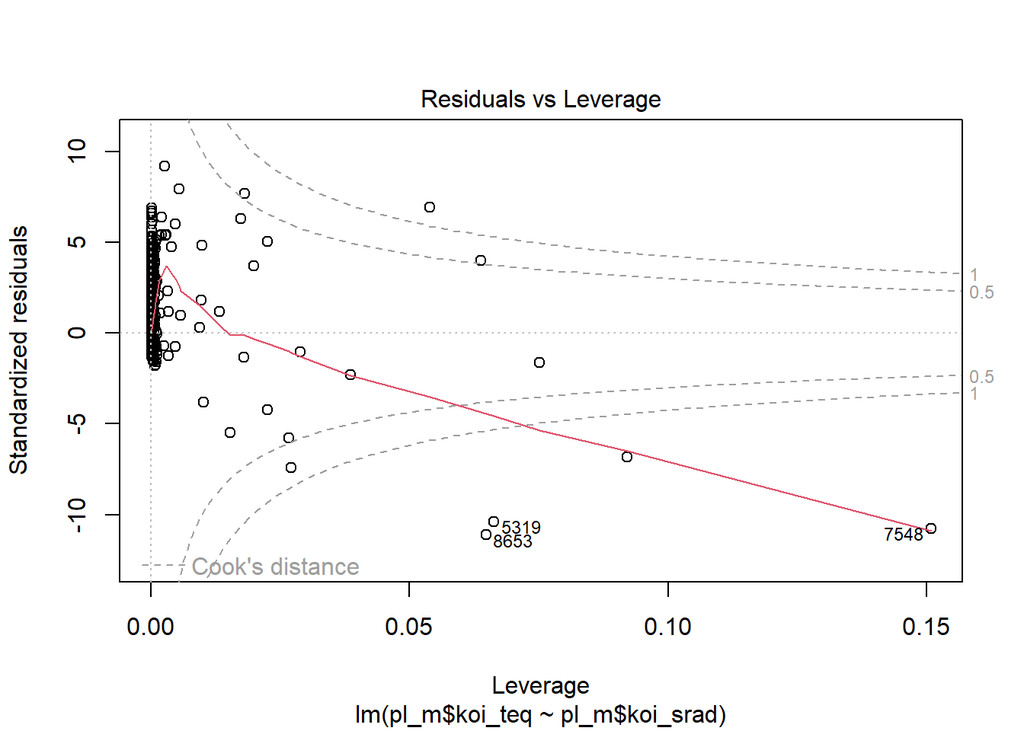

```r
plot(modelo2)
```

### COMENTARIOS SOBRE LAS GRÁFICAS

> *1. La primera gráfica muestra que el modelo lineal propuesto no esta explicando el comportamiento de la temperatura de los planetas estudiados. Esto puede deberse a la falta de correlación entre el radio del planeta y su temperatura y, a su vez, de todos los datos atipicos*

> *2.De la segunda gráfica se tiene que interpretar con cuidado porque apesar de que la mayor cantidad de los datos están sobre la recta y pareciese describir una distribución normal, los extremos se despengan mucho de la misma, por lo que no consideramos normalidad en los residuos.*

> *4. No todas las observaciones están dentro de la distancia de Cook, hay 7 observaciones dentro de nuestro conjunto de datos que están afectando nuestra regresión.*

Analizando las gráficas de residuales podemos notar que un factor claro que esta sesgando la regresión de nuestro modelo son los datos atípicos. Por lo que, como siguiente paso para mejorar el modelo, removeremos aquellos datos que se considerean atipicos para el conjunto de datos.

## Identificación de valores atípicos o influyentes en la regresión

Analicemos las variables por separado, para ello usamos un diagrama de caja y brazos.

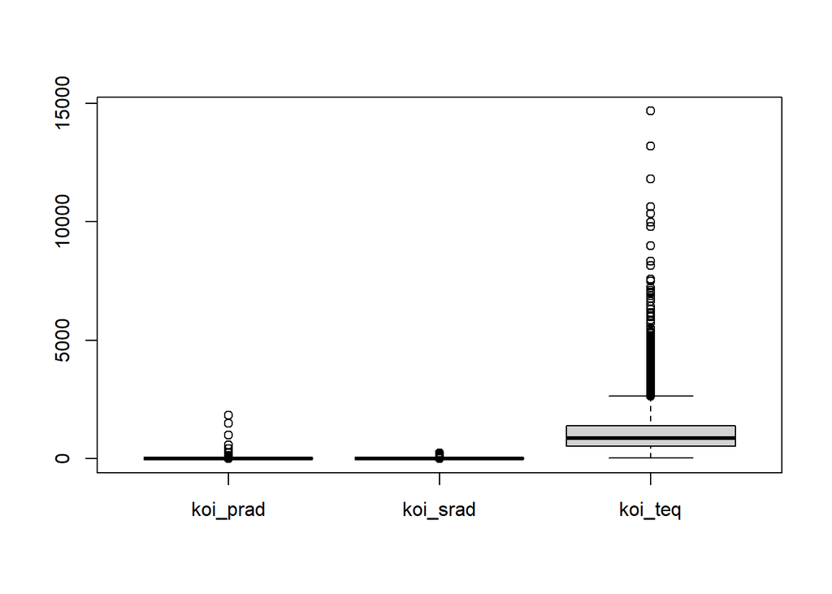

```r
boxplot.matrix(as.matrix(pl_m),use.cols = T)
```

> Analisis del diagrama de caja y brazos.

Notamos que en efecto existen una cantidad considerable de datos atipicos en cada una de las variables. Dichos datos pueden estar sesgando la regresión de nuestro modelo.

I. Criterio para detectar influyentes: $|dfbeta|>\sqrt{\frac{2}{n}}$

```r
n<- nrow(pl_1)

abs(dfbeta(modelo1))>sqrt(2/n)
```

```
##      (Intercept) pl_m$koi_srad pl_m$koi_prad
## 1           TRUE         FALSE         FALSE
## 2           TRUE         FALSE         FALSE
## 3           TRUE         FALSE         FALSE
## 4           TRUE         FALSE         FALSE
## 5           TRUE         FALSE         FALSE
## 6           TRUE         FALSE         FALSE
## 7          FALSE         FALSE         FALSE
## 8           TRUE         FALSE         FALSE
## 9           TRUE         FALSE         FALSE
## 10          TRUE         FALSE         FALSE
```

Notamos que no es claro si la mayor parte de los datos son influyentes para nuestro intersecto, se observa, además que la mayor parte de los datos no son influyentes para el coeficiente $\beta_1$ y de igual manera para el coeficiente $\beta_2$.

2. Criterio para detectar observaciones con alto “leverage”: $h_{ii}>3\frac{k}{n}$

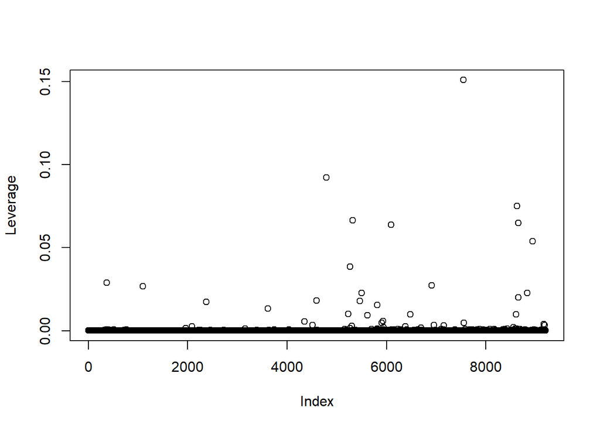

```r
lev<- hatvalues(modelo2)

plot(lev, ylab="Leverage")
```

```r
k<- 1+2

regla_leverage<- 3*(k/n); regla_leverage
```

```
## [1] 0.0009781545
```

```r
cbind(lev>regla_leverage)
```

```
##       [,1]
## 1    FALSE
## 2    FALSE
## 3    FALSE
## 4    FALSE
## 5    FALSE
## 6    FALSE
## 7    FALSE
## 8    FALSE
## 9    FALSE
## 10   FALSE
```

```r
cooks.distance(modelo2)
```

[output not shown]

# Gráfica de la distribución de nuestros datos y criterio para detectar outliers y datos leverage

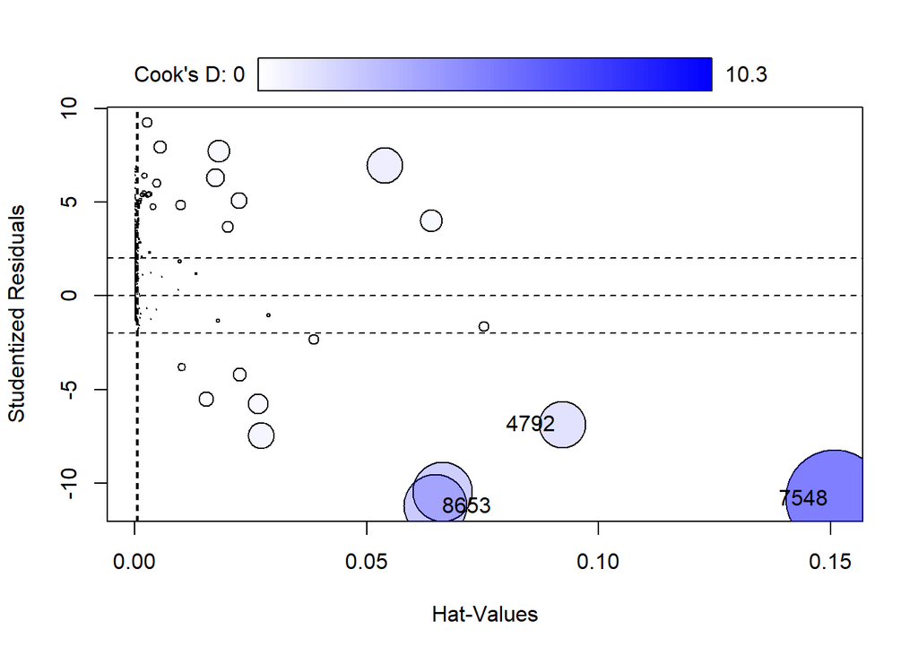

```
##         StudRes        Hat     CookD
## 4792  -6.847457 0.09213592  2.367422
## 7548 -10.820459 0.15085360 10.270424
## 8653 -11.202311 0.06478016  4.288206
```

```r
influencePlot(modelo2)
```

```r
library(olsrr)
```

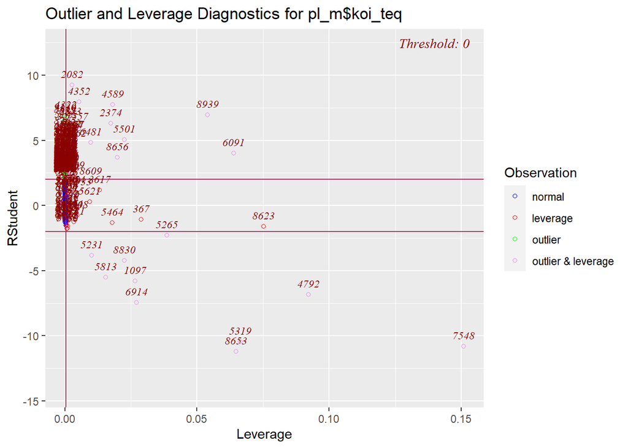

```r
ols_plot_resid_lev(modelo2)
```

Notamos que los datos que son Outliers y leverage son demasiados, es decir, que son datos que están influyendo demasiado en la regresión y es necesario hacer un análisis sin ellos.

```r
j<-outlierTest(modelo2)
```

Para ello consideramos el sub-conjunto tal que no incluya a los valores 8653, 7548, 5319, 2082, 4352, 4589, 6914, 8939, 4322, 4792 que son los datos que se identificaron como outliers dentro de nuestro conjunto “Radio solar”.

# Modelo 3

En este tercer modelo no se vana considerar las observaciones catalogadas como outliers con el objetivo de mejorar los resultados.

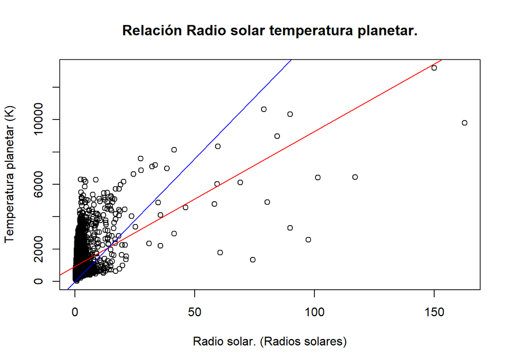

```r
pl_2<- pl_m[-c(8653,7548,5319,2082,4352,4589,6914,8939,4322,4792), ]

#Ajuste con intersecto.
fit_koi<- lm(pl_2$koi_teq~pl_2$koi_srad);

#Ajuste sin intersecto.
fit_koi1.2<- lm(pl_2$koi_teq~pl_2$koi_srad-1);

#Gráficas

plot(pl_2$koi_srad,pl_2$koi_teq,pch=1,xlab="Radio solar. (Radios solares)",ylab="Temperatura planetar (K)", main="Relación Radio solar temperatura planetar.")

abline(fit_koi,col="red")

abline(fit_koi1.2,col="blue")
```

```r
summary(fit_koi)
```

```
##
## Call:
## lm(formula = pl_2$koi_teq ~ pl_2$koi_srad)
##
## Residuals:
##     Min      1Q  Median      3Q     Max
## -6464.6  -501.5  -173.9   317.8  5152.3
##
## Coefficients:
##               Estimate Std. Error t value Pr(>|t|)
## (Intercept)    944.573      8.137   116.1   <2e-16 ***
## pl_2$koi_srad   83.256      1.731    48.1   <2e-16 ***
## ---
## Signif. codes:  0 '***' 0.001 '**' 0.01 '*' 0.05 '.' 0.1 ' ' 1
##
## Residual standard error: 733 on 9189 degrees of freedom
## Multiple R-squared:  0.2011, Adjusted R-squared:  0.201
## F-statistic:  2314 on 1 and 9189 DF,  p-value: < 2.2e-16
```

```r
summary(fit_koi1.2)
```

```
##
## Call:
## lm(formula = pl_2$koi_teq ~ pl_2$koi_srad - 1)
##
## Residuals:
##      Min       1Q   Median       3Q      Max
## -14949.8    366.6    691.7   1169.4   5931.5
##
## Coefficients:
##               Estimate Std. Error t value Pr(>|t|)
## pl_2$koi_srad  152.041      2.554   59.53   <2e-16 ***
## ---
## Signif. codes:  0 '***' 0.001 '**' 0.01 '*' 0.05 '.' 0.1 ' ' 1
##
## Residual standard error: 1151 on 9190 degrees of freedom
## Multiple R-squared:  0.2783, Adjusted R-squared:  0.2782
## F-statistic:  3544 on 1 and 9190 DF,  p-value: < 2.2e-16
```

Haciendo los cambios adecuados al modelo, hemos encontrado que la regresión es capaz de explicar el 20% del cambio en la temperatura de los planetas correctamente. Tenemos un error estadar muy alto, pero el error del intersepto y el coeficientes $\beta_1$ no tienen valores significantes. Inclusive nuestro coeficiente p sigue siendo bajo.

Como previamente se dijo, el intersepto se interpreta como la temperatura promedio registrada por el satélite sin presencia de una estrella, en este caso 944.573 K. El coefeciente $\beta_1=83.256$ se interpreta como el cambio promedio a razón del radio solar de la temperatura del planeta.

##Comparación de los modelos. Tabla.1 Comparativa de modelos donde x representa la variable radio del sol, y el radio del planeta.

[output not shown]

# Intervalos de confianza de 0.95

```r
ic1<- confint(fit_koi, level=0.95); ic1
```

```
##                   2.5 %    97.5 %
## (Intercept)   928.62264 960.52393
## pl_2$koi_srad  79.86332  86.64936
```

> *Intercepto

> *Coeficiente $\beta_1$

### Transformacion BoxCox Sobre el modelo 1.

Por úlitmo, vamosa realizar una prueba sobre nuestras variables para ver a que variables podemos aplicar una transformación BoxCox

```r
library(nortest)
lillie.test(pl_m$koi_teq)
```

```
##
##  Lilliefors (Kolmogorov-Smirnov) normality test
##
## data:  pl_m$koi_teq
## D = 0.14005, p-value < 2.2e-16
```

```r
lillie.test(pl_m$koi_srad)
```

```
##
##  Lilliefors (Kolmogorov-Smirnov) normality test
##
## data:  pl_m$koi_srad
## D = 0.40761, p-value < 2.2e-16
```

```r
lillie.test(pl_m$koi_prad)
```

```
##
##  Lilliefors (Kolmogorov-Smirnov) normality test
##
## data:  pl_m$koi_prad
## D = 0.48668, p-value < 2.2e-16
```

```r
library(DescTools)
lambda.opt1<- BoxCoxLambda(pl_2$koi_teq, method= "loglik", lower=-5, upper=5); lambda.opt1
```

```
## [1] 0.05
```

```r
lambda.opt2<- BoxCoxLambda(pl_2$koi_srad, method= "loglik", lower=-5, upper=5); lambda.opt2
```

```
## [1] -0.55
```

```r
Temperatura<-lillie.test(pl_2$koi_teq^(0.05)/(0.05));Temperatura
```

```
##
##  Lilliefors (Kolmogorov-Smirnov) normality test
##
## data:  pl_2$koi_teq^(0.05)/(0.05)
## D = 0.020623, p-value = 2.047e-09
```

```r
Radio_solar<-lillie.test(pl_2$koi_srad^(-0.55)/(-0.55));Radio_solar
```

```
##
##  Lilliefors (Kolmogorov-Smirnov) normality test
##
## data:  pl_2$koi_srad^(-0.55)/(-0.55)
## D = 0.089499, p-value < 2.2e-16
```

Vemos que después de aplicar la transformación BoxCox nuestros datos siguen sin presentar normalidad dado que los valores de “p” son muy pequeños.

### CONCLUSION:

En el segúndo modelo se decidió remover la variable radio del planeta por su alto error en el primer modelo y su baja relevancia estadísitica. Se obtuvo que el intersecto del modelo era de $979.11 K$ y el cambio promedio en la temperatura del planeta a razón del radio del sol era de $61.47$ K, ambas variables con significacia estadistica en el modelo. Desafortunadamente el modelo no explicaba más del $19.3%$ del fenomeno estudiado y el error estandar de los residuos seguía siendo muy alto, por lo que se decidó hacer una prueba que nos permitiese ver cuales eran los datos con mayor relevancia en el modelo y cuales eran outliers. Se encontraron 10 outliers por lo que para un tercer modelo se removieron.

En nuestro tercer y ultimo modelo obtivimos una mejora del $0.7%$ a la hora de explicar el fenómeno con el modelo propuesto. Se obtuvo un intersecto de $944.57$k y un coeficiente $\beta_1$=83.256k, ambos con significancia estadística y con errores no relevantes según su valor real. Se realizó una transformación BoxCox de nuestros datos, pero esto no logro normalizar las variables.

Se hizo un ultimo modelo sin intersepto, capaz de explicar el $27%$ del fenómeno, pero este ultimo fue descartado ya que no es coherente con la realidad, ningún planeta puede tener una temperatura promedio de 0 k. Algo que vale la pena recalcar es que la temperatura registrada en cada uno de los intersectos es muy alta, y pareciera que hay algún otro factor que está modificando las mediciones. Una posible razón a estos resultados puede ser que los planetas registrados en el conjunto de datos, tenían orbitas muy cercanas al sol o que su composición permitía mantener temperaturas muy altas, por lo que una mejora a este modelo sería agregar y analizar ese tipo de variables.